# Machine Learning Project

Russ Bjork

12/26/2020

## Environment setup and configuration:

### Libraries Silently Loaded

## Project Overview:

Using devices such as Jawbone Up, Nike FuelBand, and Fitbit it is now possible to collect a large amount of data about personal activity relatively inexpensively. These type of devices are part of the quantified self movement – a group of enthusiasts who take measurements about themselves regularly to improve their health, to find patterns in their behavior, or because they are tech geeks. One thing that people regularly do is quantify how much of a particular activity they do, but they rarely quantify how well they do it. In this project, your goal will be to use data from accelerometers on the belt, forearm, arm, and dumbell of 6 participants. They were asked to perform barbell lifts correctly and incorrectly in 5 different ways. More information is available from the website here:  
http://groupware.les.inf.puc-rio.br/har (see the section on the Weight Lifting Exercise Dataset).

The training data for this project are available here:  
https://d396qusza40orc.cloudfront.net/predmachlearn/pml-training.csv

The test data are available here:  
https://d396qusza40orc.cloudfront.net/predmachlearn/pml-testing.csv

## Data loading and exploration:

The training data set is made of 19622 observations on 160 columns. Many of the columns have NA values or blank values on almost every observation. The covariants with low or zero variability will be removed because they will not produce any information. The first seven columns give information about the people who did the test, and also timestamps. The first seven columns will be removed as they add no value to the models.

```r
traindata <- read_csv("Data/pml-training.csv")
#head(traindata)
#summary(traindata)
dim(traindata)
```

```
## [1] 19622   160
```

```r
#names(traindata)
#table(traindata$classe)

testdata <- read_csv("Data/pml-testing.csv")
#head(testdata)
#summary(traindata)
dim(testdata)
```

```
## [1]  20 160
```

## Data cleansing and tiddying:

All the variables containing NA or blanks are removed from the raw data. Variables with very low or zero variability are removed as these columns add no predictive value. The first seven variables are being removed as they are descriptive of who and when regarding the event data and serve no purpose in the prediction models.

```r
remove <- which(colSums(is.na(traindata) | traindata=="")>0.9*dim(traindata)[1])
traindata <- traindata[,-remove]
traindata <- traindata[,-c(1:7)]
dim(traindata)
```

```
## [1] 19622    53
```

```r
#str(traindata)

remove <- which(colSums(is.na(testdata) | testdata=="")>0.9*dim(testdata)[1])
testdata <- testdata[,-remove]
testdata <- testdata[,-c(1:7)]
dim(testdata)
```

```
## [1] 20 53
```

```r
#str(testdata)
```

The tidy data is prepared to be segmented into training and validation data sets, each comprised of 53 columns.

## Create training and validation sets:

From the tidy data, 3 data sets will be created. The first is the training set. The second in the validation set. These are both created from the original training data. The third is the testing set. The testing set comes from the original test data. All sets of data have the exact same set of cleanup/tidy procedures applied. All sets are comprised of 53 columns/covariants.

```r
set.seed(12345)
intrain <- createDataPartition(y=traindata$classe, p=0.75, list=FALSE)
training <- traindata[intrain,]
validation <- traindata[-intrain,]
dim(training)
```

```
## [1] 14718    53
```

```r
dim(validation)
```

```
## [1] 4904   53
```

```r
#summary(validation$classe)
#summary(training$classe)
```

## Build the different models:

In the following sections, we will test 3 different models : * classification tree * random forest * gradient boosting method

In order to limit the effects of overfitting, and improve the efficicency of the models, we will use the *cross-validation technique. We will use 5 folds (usually, 5 or 10 can be used, but 10 folds gives higher run times with no significant increase of the accuracy). ### Classification Tree

```r
control <- trainControl(method="cv", number=5)
model1 <- train(classe~., data=training, method="rpart", trControl=control)
print(model1$finalModel)
```

```
## n= 14718
##
## node), split, n, loss, yval, (yprob)
##       * denotes terminal node
##
##  1) root 14718 10533 A (0.28 0.19 0.17 0.16 0.18)
##    2) roll_belt< 129.5 13394  9260 A (0.31 0.21 0.19 0.18 0.11)
##      4) pitch_forearm< -33.95 1184     9 A (0.99 0.0076 0 0 0) *
##      5) pitch_forearm>=-33.95 12210  9251 A (0.24 0.23 0.21 0.2 0.12)
##       10) magnet_dumbbell_y< 437.5 10319  7420 A (0.28 0.18 0.24 0.19 0.11)
##         20) roll_forearm< 123.5 6382  3795 A (0.41 0.18 0.18 0.17 0.059) *
##         21) roll_forearm>=123.5 3937  2607 C (0.079 0.18 0.34 0.23 0.18) *
##       11) magnet_dumbbell_y>=437.5 1891   912 B (0.032 0.52 0.045 0.23 0.18) *
##    3) roll_belt>=129.5 1324    51 E (0.039 0 0 0 0.96) *
```

[figure not shown]

```r
fancyRpartPlot(model1$finalModel)
```

### Random Forest

```r
control <- trainControl(method="cv", number=5)
model2 <- train(classe~., data=training, method="rf", trControl=control, verbose=FALSE)
print(model2)
```

```
## Random Forest
##
## 14718 samples
##    52 predictor
##     5 classes: 'A', 'B', 'C', 'D', 'E'
##
## No pre-processing
## Resampling: Cross-Validated (5 fold)
## Summary of sample sizes: 11774, 11774, 11774, 11775, 11775
## Resampling results across tuning parameters:
##
##   mtry  Accuracy   Kappa
##    2    0.9919826  0.9898578
##   27    0.9913030  0.9889986
##   52    0.9851202  0.9811766
##
## Accuracy was used to select the optimal model using the largest value.
## The final value used for the model was mtry = 2.
```

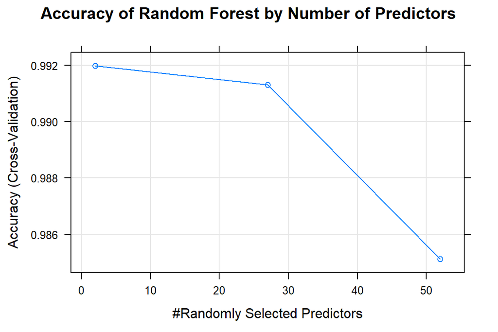

```r
plot(model2, main="Accuracy of Random Forest by Number of Predictors")
```

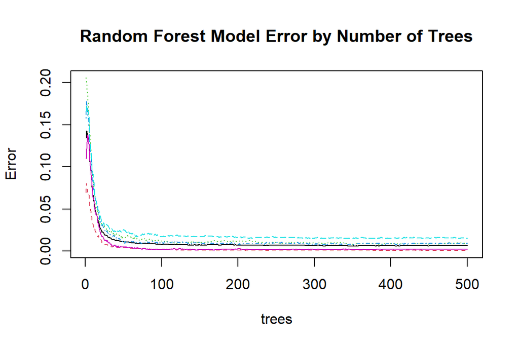

```r
plot(model2$finalModel,main="Random Forest Model Error by Number of Trees")
```

### Gradient Boost

```r
control <- trainControl(method="cv", number=5)
model3 <- train(classe~., data=training, method="gbm", trControl=control, verbose=FALSE)
print(model3)
```

```
## Stochastic Gradient Boosting
##
## 14718 samples
##    52 predictor
##     5 classes: 'A', 'B', 'C', 'D', 'E'
##
## No pre-processing
## Resampling: Cross-Validated (5 fold)
## Summary of sample sizes: 11775, 11775, 11773, 11775, 11774
## Resampling results across tuning parameters:
##
##   interaction.depth  n.trees  Accuracy   Kappa
##   1                   50      0.7462973  0.6781972
##   1                  100      0.8225303  0.7753540
##   1                  150      0.8533772  0.8144003
##   2                   50      0.8530367  0.8138575
##   2                  100      0.9056940  0.8806589
##   2                  150      0.9315808  0.9134275
##   3                   50      0.8986280  0.8716423
##   3                  100      0.9451697  0.9306158
##   3                  150      0.9612723  0.9510047
##
## Tuning parameter 'shrinkage' was held constant at a value of 0.1
##
## Tuning parameter 'n.minobsinnode' was held constant at a value of 10
## Accuracy was used to select the optimal model using the largest value.
## The final values used for the model were n.trees = 150, interaction.depth =
##  3, shrinkage = 0.1 and n.minobsinnode = 10.
```

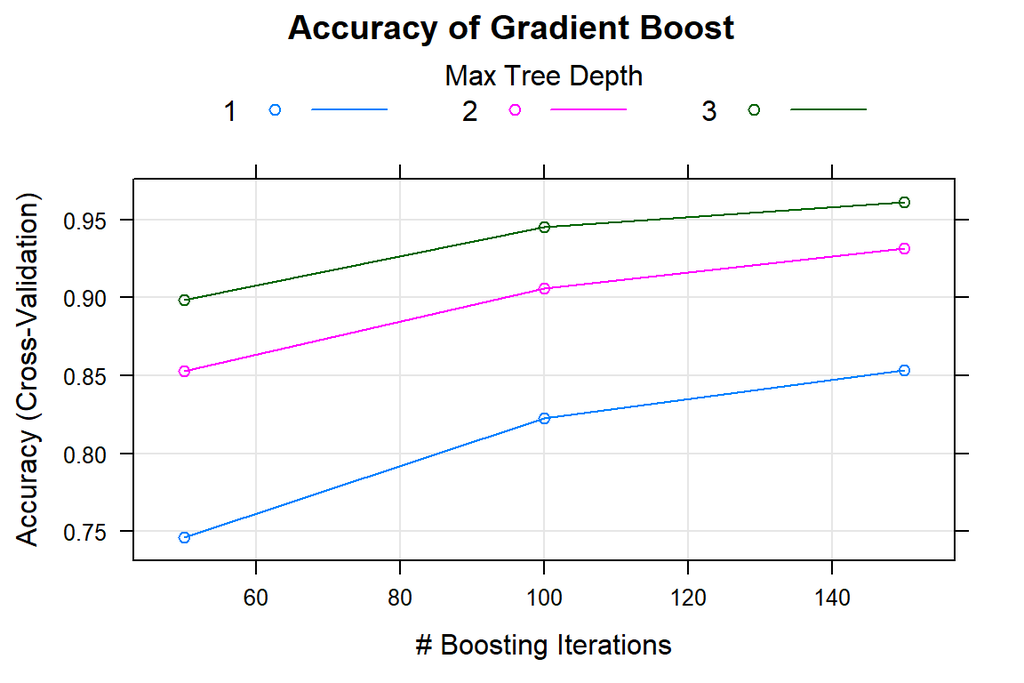

```r
plot(model3, main="Accuracy of Gradient Boost")
```

## Predictions from the different models:

### Classification Tree

Classification Tree generates an accuracy of 48.8% using cross-validation with 5 steps.

```r
pred1 <- predict(model1, newdata=validation)
confmat1 <- confusionMatrix(as.factor(validation$classe), pred1)
confmat1$table
```

```
##           Reference
## Prediction    A    B    C    D    E
##          A 1252   30   90    0   23
##          B  396  317  236    0    0
##          C  434   24  397    0    0
##          D  343  151  310    0    0
##          E  114  132  229    0  426
```

```r
confmat1$overall[1]
```

```
##  Accuracy
## 0.4877651
```

### Random Forest

Random Forest generates an accuracy of 99.4% using cross-validation with 5 steps.

```r
pred2 <- predict(model2, newdata=validation)
confmat2 <- confusionMatrix(as.factor(validation$classe), pred2)
confmat2$table
```

```
##           Reference
## Prediction    A    B    C    D    E
##          A 1395    0    0    0    0
##          B    1  947    1    0    0
##          C    0    6  848    1    0
##          D    0    0   15  784    5
##          E    0    0    0    1  900
```

```r
confmat2$overall[1]
```

```
##  Accuracy
## 0.9938825
```

### Gradient Boost

Gradient Boost generates an accuracy of 96.0% using cross-validation with 5 steps.

```r
pred3 <- predict(model3, newdata=validation)
confmat3 <- confusionMatrix(as.factor(validation$classe), pred3)
confmat3$table
```

```
##           Reference
## Prediction    A    B    C    D    E
##          A 1371   17    1    6    0
##          B   23  896   28    2    0
##          C    0   29  810   16    0
##          D    0    2   38  760    4
##          E    0    8   10   10  873
```

```r
confmat3$overall[1]
```

```
##  Accuracy
## 0.9604405
```

## Conclusion:

Based on the prediction outcomes, the Random Forest model (model 2) is the best model. Model 2 will be used to predict the values for “classe” for the test data set.

```r
predtest <- predict(model2,newdata=testdata)
predtest
```

```
##  [1] B A B A A E D B A A B C B A E E A B B B
## Levels: A B C D E
```

```r
critvars <- varImp(model2)
critvars
```

```
## rf variable importance
##
##   only 20 most important variables shown (out of 52)
##
##                      Overall
## roll_belt             100.00
## yaw_belt               84.34
## magnet_dumbbell_z      70.43
## pitch_belt             68.57
## magnet_dumbbell_y      66.35
## pitch_forearm          64.98
## magnet_dumbbell_x      58.47
## roll_forearm           54.69
## magnet_belt_z          48.50
## accel_dumbbell_y       47.87
## accel_belt_z           47.45
## magnet_belt_y          46.91
## roll_dumbbell          44.95
## accel_dumbbell_z       38.86
## roll_arm               36.37
## accel_forearm_x        34.36
## gyros_belt_z           32.40
## accel_arm_x            30.69
## accel_dumbbell_x       30.69
## total_accel_dumbbell   29.33
```